# DataAnalysis

Marco Lee

January 23, 2020

# Reading data from .csv file

```r
MData<-read.csv("Data/measurements.csv")
str(MData)
```

```
## 'data.frame':    10 obs. of  5 variables:
##  $ Species    : Factor w/ 10 levels "Actias luna",..: 3 1 10 2 8 4 7 5 9 6
##  $ Limb.Width : num  19.72 12.09 34.74 28.83 2.23 ...
##  $ unitsW     : Factor w/ 2 levels "cm","mm": 1 2 2 1 1 1 1 1 2 2
##  $ Limb.Length: num  101.55 3.46 136.32 236.41 45.9 ...
##  $ unitsL     : Factor w/ 2 levels "cm","mm": 2 2 2 1 2 1 1 2 2 1
```

```r
head(MData)
```

```
##                  Species Limb.Width unitsW Limb.Length unitsL
## 1          Attacus atlas  19.719012     cm  101.551027     mm
## 2            Actias luna  12.094866     mm    3.458552     mm
## 3    Plutella xylostella  34.739687     mm  136.315778     mm
## 4      Adoxophyes honmai  28.828226     cm  236.409295     cm
## 5       Lymantria dispar   2.233992     cm   45.898930     mm
## 6 Bhutanitis lidderdalei  10.296228     cm   69.568396     cm
```

### Renaming columns for ease of coding

Column names are abbreviated.

```r
MData<-rename(MData, spe = Species, lbW = Limb.Width, unW = unitsW, lbL = Limb.Length, unL = unitsL)
```

# Analysing data

## Standardizing units

Units are all converted to cm.

```r
for(i in 1:nrow(MData)){ #converting limb width
  if(MData[i,]$unW == "mm"){
    MData[i,]$lbW <- MData[i,]$lbW * 0.1
    MData[i,]$unW <- "cm"
  }
}

for(i in 1:nrow(MData)){ #converting limb length
  if(MData[i,]$unL == "mm"){
    MData[i,]$lbL <- MData[i,]$lbL * 0.1
    MData[i,]$unL <- "cm"
  }
}
str(MData)
```

```
## 'data.frame':    10 obs. of  5 variables:
##  $ spe: Factor w/ 10 levels "Actias luna",..: 3 1 10 2 8 4 7 5 9 6
##  $ lbW: num  19.72 1.21 3.47 28.83 2.23 ...
##  $ unW: Factor w/ 2 levels "cm","mm": 1 1 1 1 1 1 1 1 1 1
##  $ lbL: num  10.155 0.346 13.632 236.409 4.59 ...
##  $ unL: Factor w/ 2 levels "cm","mm": 1 1 1 1 1 1 1 1 1 1
```

## Calculating limb volume

Limb volume is calculated by assuming that limb is a cylinder with the width as diameter and the length as height. The formula used is pi* (r^2) * h. The unit is cm^3

```r
MData<-mutate(MData,
              lbV = pi*(lbW/2)^2*lbL)
head(MData)
```

```
##                      spe       lbW unW         lbL unL          lbV
## 1          Attacus atlas 19.719012  cm  10.1551027  cm 3.101305e+03
## 2            Actias luna  1.209487  cm   0.3458552  cm 3.973620e-01
## 3    Plutella xylostella  3.473969  cm  13.6315778  cm 1.292075e+02
## 4      Adoxophyes honmai 28.828226  cm 236.4092952  cm 1.543087e+05
## 5       Lymantria dispar  2.233992  cm   4.5898930  cm 1.799102e+01
## 6 Bhutanitis lidderdalei 10.296228  cm  69.5683963  cm 5.792395e+03
```

## Grouping species

Species were grouped in moths or butterflies.

```r
MData$spe
```

```
##  [1] Attacus atlas          Actias luna            Plutella xylostella
##  [4] Adoxophyes honmai      Lymantria dispar       Bhutanitis lidderdalei
##  [7] Deramas livens         Bombyx mori            Manduca sexta
## [10] Danaus plexippus
## 10 Levels: Actias luna Adoxophyes honmai ... Plutella xylostella
```

```r
MData<- mutate(MData, grp=rep(NA, 10))
MData$grp<- c(1,1,1,1,1,0,0,1,1,0)
MData$grp<- ifelse(MData$grp==T, "Moth", "Butterfly")
select(MData, spe, grp)
```

```
##                       spe       grp
## 1           Attacus atlas      Moth
## 2             Actias luna      Moth
## 3     Plutella xylostella      Moth
## 4       Adoxophyes honmai      Moth
## 5        Lymantria dispar      Moth
## 6  Bhutanitis lidderdalei Butterfly
## 7          Deramas livens Butterfly
## 8             Bombyx mori      Moth
## 9           Manduca sexta      Moth
## 10       Danaus plexippus Butterfly
```

## Group dimensions

Mean and standard deviation are calculated for width, length, and volume for each group.

```r
avg<-MData
avg<- avg %>%
  group_by(grp) %>%
  summarize(meanW=mean(lbW), SDW=sd(lbW),
           meanL=mean(lbL), SDL=sd(lbL),
           meanV=mean(lbV), SDV=sd(lbV)) %>%
  arrange(grp) #arrange in alphabetic order of group name
avg
```

```
## # A tibble: 2 x 7
##   grp       meanW   SDW meanL   SDL  meanV    SDV
##   <chr>     <dbl> <dbl> <dbl> <dbl>  <dbl>  <dbl>
## 1 Butterfly  9.79  7.90  70.9  68.5  2272.  3056.
## 2 Moth      10.0  11.0   40.7  86.5 22839. 57987.
```

#Graphs Width is plotted against length of all species.

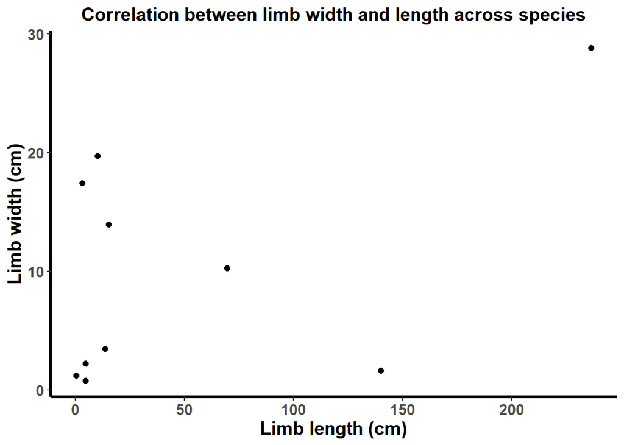

```r
ggplot(data=MData, aes(x=lbL, y=lbW)) +
  geom_point(size=I(2))+
  ylab("Limb width (cm)") +
  xlab("Limb length (cm)") +
  theme_classic() +
  theme(axis.line=element_line(colour = 'black', size = 1.2),
        axis.text=element_text(size=I(12), face="bold"),
        axis.title=element_text(size=I(15), face="bold"),
        plot.title=element_text(size=I(15), face="bold", hjust=0.5)) +
  ggtitle("Correlation between limb width and length across species")
```

### Species with above average volume

Only species with volume above the average of their respective group is included when graphing. First, a data frame “x” with only species that fitted the criteria is created.

```r
x<-MData[(MData$grp == "Moth" & MData$lbV > as.integer(avg[2,6]))|
           (MData$grp =="Butterfly" &MData$lbV > as.integer(avg[1,6])),]
x
```

```
##                      spe      lbW unW      lbL unL        lbV       grp
## 4      Adoxophyes honmai 28.82823  cm 236.4093  cm 154308.652      Moth
## 6 Bhutanitis lidderdalei 10.29623  cm  69.5684  cm   5792.395 Butterfly
```

Then, a scatterplot with limb width against length is created with this set of data (species with above average limb volume)

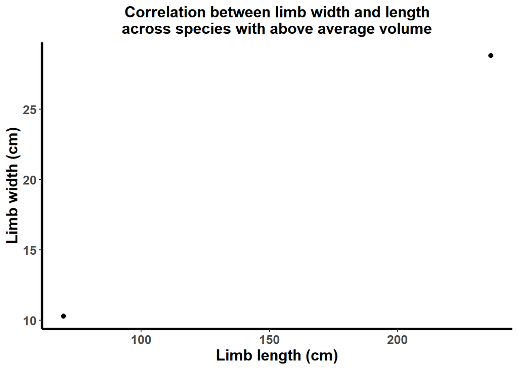

```r
ggplot(data=x, aes(x=lbL, y=lbW)) +
  geom_point(size=I(2))+
  ylab("Limb width (cm)") +
  xlab("Limb length (cm)") +
  theme_classic() +
  theme(axis.line=element_line(colour = 'black', size = 1.2),
        axis.text=element_text(size=I(12), face="bold"),
        axis.title=element_text(size=I(15), face="bold"),
        plot.title=element_text(size=I(15), face="bold", hjust=0.5)) +
  ggtitle("Correlation between limb width and length\nacross species with above average volume")
```

### Species with below average limb volume

First, a data frame “y” with only species that fitted the criteria is created.

```r
y<-MData[(MData$grp == "Moth" & MData$lbV < as.integer(avg[2,6]))|
           (MData$grp =="Butterfly" &MData$lbV < as.integer(avg[1,6])),]
```

Then, the columns “species”" and “limb” volumn are selected and displayed.

```r
z<-select(MData, spe, lbV)
z<-rename(z, Species=spe, Limb.Volume=lbV) #renaming columns
z
```

```
##                   Species  Limb.Volume
## 1           Attacus atlas 3.101305e+03
## 2             Actias luna 3.973620e-01
## 3     Plutella xylostella 1.292075e+02
## 4       Adoxophyes honmai 1.543087e+05
## 5        Lymantria dispar 1.799102e+01
## 6  Bhutanitis lidderdalei 5.792395e+03
## 7          Deramas livens 7.228340e+02
## 8             Bombyx mori 2.310359e+03
## 9           Manduca sexta 2.395275e+00
## 10       Danaus plexippus 3.009773e+02
```